# Post-Processing Exploratory Data Analysis

## Initialization.

In this notebook, we will need pandas to read/process data and matplotlib to plot data.

```python
%matplotlib inline
import pandas as pd
import numpy as np
import matplotlib
import matplotlib.pyplot as plt
import seaborn
import re
import datetime
pd.options.display.max_columns=200
matplotlib.rcParams['figure.figsize'] = (15.0, 12.0)
```

Column names of data file:

```python
summaryfile_type = {'Unnamed':int,
                    'Unnamed2':int,
                    'LOAN_ID':object,
                    'ORIG_CHN':object,
                    'Seller.Name':object,
                    'ORIG_RT':float,
                    'ORIG_AMT':float,
                    'ORIG_TRM':float,
                    'ORIG_DTE':object,
                    'FRST_DTE':object,
                    'OLTV':float,
                    'OCLTV':float,
                    'NUM_BO':float,
                    'DTI':float,
                    'CSCORE_B':float,
                    'FTHB_FLG':object,
                    'PURPOSE':object,
                    'PROP_TYP':object,
                    'NUM_UNIT':int,
                    'OCC_STAT':object,
                    'STATE':object,
                    'ZIP_3':object,
                    'MI_PCT':float,
                    'Product.Type':object,
                    'CSCORE_C':float,
                    'Monthly.Rpt.Prd':object,
                    'Servicer.Name':object,
                    'LAST_RT':float,
                    'LAST_UPB':float,
                    'Loan.Age':float,
                    'Months.To.Legal.Mat':float,
                    'Adj.Month.To.Mat':float,
                    'Maturity.Date':object,
                    'MSA':int,
                    'Delq.Status':object,
                    'MOD_FLAG':object,
                    'Zero.Bal.Code':float,
                    'ZB_DTE':object,
                    'LPI_DTE':object,
                    'FCC_DTE':object,
                    'DISP_DT':object
}
```

## Read data into memory and process the data

```python
fannie1 = pd.read_csv('./processed/total/total_2012.csv', dtype=summaryfile_type, nrows=10000000)
fannie1.drop(fannie1.columns[:1], axis=1, inplace=True)
fannie1.rename(columns=lambda x: re.sub('[.]','_',x), inplace=True)
fannie1.head()
```

|  | LOAN_ID | ORIG_CHN | Seller_Name | ORIG_RT | ORIG_AMT | ORIG_TRM | ORIG_DTE | FRST_DTE | OLTV | OCLTV | NUM_BO | DTI | CSCORE_B | FTHB_FLG | PURPOSE | PROP_TYP | NUM_UNIT | OCC_STAT | STATE | ZIP_3 | MI_PCT | Product_Type | CSCORE_C | Monthly_Rpt_Prd | Servicer_Name | LAST_RT | LAST_UPB | Loan_Age | Months_To_Legal_Mat | … |
| --- | --- | --- | --- | --- | --- | --- | --- | --- | --- | --- | --- | --- | --- | --- | --- | --- | --- | --- | --- | --- | --- | --- | --- | --- | --- | --- | --- | --- | --- | --- |
| 0 | 100001726155 | B | STEARNS LENDING, LLC | 3.500 | 278000.0 | 360.0 | 12/2012 | 02/2013 | 77.0 | 77.0 | 1.0 | 36.0 | 802.0 | N | R | SF | 1 | P | CA | 949 | NaN | FRM | NaN | 09/01/2015 | OTHER | 3.500 | 258940.15 | 32.0 | 328.0 | … |
| 1 | 100003164216 | R | OTHER | 3.625 | 478000.0 | 360.0 | 11/2012 | 01/2013 | 68.0 | 68.0 | 2.0 | 25.0 | 763.0 | N | R | PU | 1 | P | CA | 913 | NaN | FRM | 742.0 | 09/01/2015 | OTHER | 3.625 | 452501.57 | 33.0 | 327.0 | … |
| 2 | 100008218145 | C | FLAGSTAR CAPITAL MARKETS CORPORATION | 3.625 | 403000.0 | 360.0 | 09/2012 | 11/2012 | 54.0 | 61.0 | 2.0 | 33.0 | 749.0 | N | R | SF | 1 | P | WA | 981 | NaN | FRM | 747.0 | 08/01/2014 | MATRIX FINANCIAL SERVICES CORPORATION | 3.625 | 389568.37 | 22.0 | 338.0 | … |
| 3 | 100009252313 | C | WELLS FARGO BANK, N.A. | 3.625 | 626000.0 | 360.0 | 09/2012 | 11/2012 | 78.0 | 78.0 | 1.0 | 24.0 | 800.0 | N | R | SF | 1 | P | VA | 220 | NaN | FRM | NaN | 09/01/2015 | WELLS FARGO BANK, N.A. | 3.625 | 590002.26 | 35.0 | 325.0 | … |
| 4 | 100009333533 | C | JPMORGAN CHASE BANK, NATIONAL ASSOCIATION | 3.625 | 130000.0 | 360.0 | 10/2012 | 12/2012 | 80.0 | 80.0 | 2.0 | 41.0 | 758.0 | Y | P | SF | 1 | P | IL | 601 | NaN | FRM | 749.0 | 09/01/2015 | JP MORGAN CHASE BANK, NA | 3.625 | 122262.89 | 34.0 | 326.0 | … |

```python
# All helper functions!
def extract_status_year(df, col, x):
    '''
    This function is to extract the year of last report time. For groupby purpose
    Instead of using the datetime object, let's use the string function to extract year
    '''
    return df.ix[x,col].split('/')[-1]

def extract_credit_score(x,y):
    temp = x.copy()
    temp[x.isnull()] = y.loc[x.isnull()]
    temp[x>y] = y[x>y]
    #x[x>y] = y[x>y]

    return temp
def extract_status_default(df, x):
    '''
    This function is to extract the year of last report time. For groupby purpose
    Instead of using the datetime object, let's use the string function to extract year
    '''
    if (df.ix[x,'Zero_Bal_Code'] == 0) or (df.ix[x,'Zero_Bal_Code'] == 1):
        return 'Healthy'
    elif (df.ix[x,'Zero_Bal_Code'] == 3) or (df.ix[x,'Zero_Bal_Code'] == 6) or (df.ix[x,'Zero_Bal_Code'] == 9):
        return 'Default'
    else:
        return 'NA'
```

```python
# Processing the credit score: Take the lower credit score from two scores if both are available
credit = extract_credit_score(fannie1['CSCORE_B'],fannie1['CSCORE_C'])
fannie1.drop(['CSCORE_B','CSCORE_C'],axis = 1, inplace=True)
fannie1['CSCORE'] = credit
```

# Analysis of data from 2000 to 2012

## Evolution of default rate

```python
# Total number of record
total_num = len(fannie1)
print("Total number of record is: {}".format(total_num))
```

```
Total number of record is: 10000000
```

```python
# Number of prepaid
total_prepaid = len(fannie1.ix[fannie1['Zero_Bal_Code'] == 1])
print("Total number of prepaid is {}".format(total_prepaid))
print("Total prepaid ratio is {}".format(total_prepaid/total_num))
```

```
Total number of prepaid is 6282546
Total prepaid ratio is 0.6282546
```

```python
fannie1_default = fannie1.ix[(fannie1['Zero_Bal_Code'] == 9) | (fannie1['Zero_Bal_Code'] == 6) |
                              (fannie1['Zero_Bal_Code'] == 9)]
# Number of default
total_default = len(fannie1_default)
print("Total number of default is: {}".format(total_default))
print("Total default ratio is {}".format(total_default/total_num))
```

```
Total number of default is: 247709
Total default ratio is 0.0247709
```

```python
total_default_by_year = fannie1_default.groupby(lambda x:extract_status_year(fannie1,'Monthly_Rpt_Prd',x))['LOAN_ID'].count()
total_by_year = fannie1.groupby(lambda x:extract_status_year(fannie1,'ORIG_DTE',x))['LOAN_ID'].count()
```

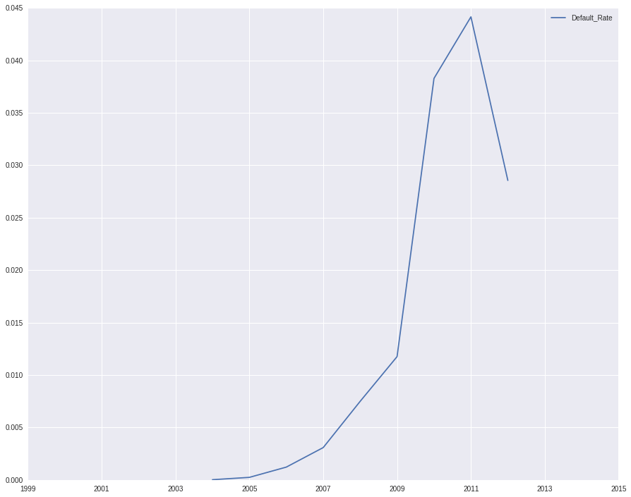

```python
total_default_by_year.name='Default number'
total_by_year.name='Total number'
default_rate_by_year = pd.concat([total_default_by_year,total_by_year],axis = 1, join='outer')
default_rate_by_year['Default_Rate'] = default_rate_by_year['Default number']/default_rate_by_year['Total number']
default_rate_by_year.plot(y='Default_Rate')
```

### Some comments about the default rate evolution

From the plot above, there is a tendency to say the default rate peaks at 2011. However, this dataset is just a subset of all Fannie's single family data. Also, many loan won't default in a short period of time. These factors all contribute to the increase of default rate at 2011. The dataset also cuts off in 2012, which probably explains why we see a decrease after 2011.

## Number of applicants per year

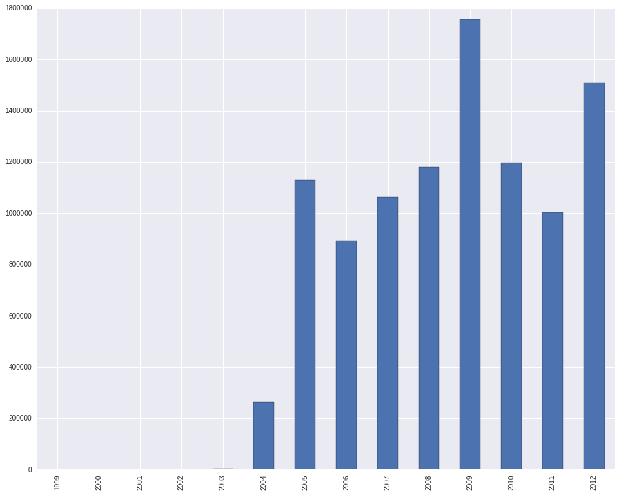

```python
total_applications_by_year = fannie1.groupby(lambda x:extract_status_year(fannie1,'ORIG_DTE',x))['LOAN_ID'].count()
total_applications_by_year.plot(kind='bar')
```

## The evolution of interest rate by year

```python
rate_by_year = fannie1.groupby(lambda x:extract_status_year(fannie1,'ORIG_DTE',x))['ORIG_RT'].mean()
```

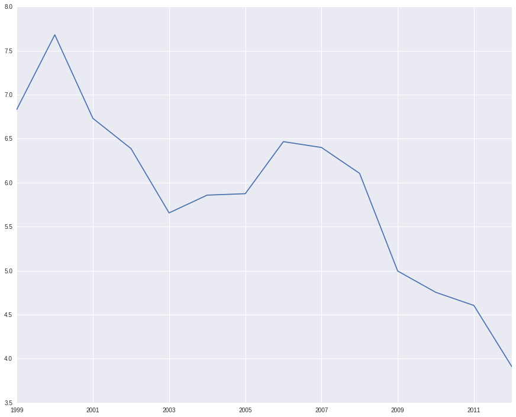

```python
rate_by_year.plot()
```

```python
# Any different in each state?
rate_by_year_state = fannie1.groupby([lambda x:extract_status_year(fannie1,'ORIG_DTE',x),'STATE'])['ORIG_RT'].mean()
```

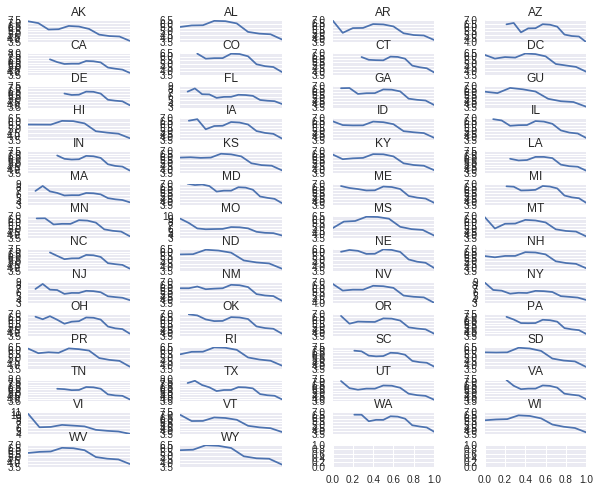

```python
rate_by_year_state = rate_by_year_state.unstack(level=0)

i = int(np.ceil(fannie1['STATE'].nunique()/4))
j = 4
fig, axes = plt.subplots(i,j, figsize=(10, 8))
plt.subplots_adjust(wspace=0.5, hspace=0.5)
i2 = 0
j2=0
for state in rate_by_year_state.index:
    axes[i2,j2].plot(rate_by_year_state.ix[state,])
    axes[i2,j2].set_title(state)
    axes[i2,j2].get_xaxis().set_visible(False)
    j2 += 1
    if j2 > 3:
        i2 += 1
        i2 = i2 % i
    j2 = j2 % j
```

### Comments on rates by states plot

Some states, like North Dakota (ND) show an upward trend in early 2000s even the general trend of interest rate is going down. This is very interesting. I think this may related to its specific booming economy in that state, like oil (drilling in ND).

## Default cases in each year

Still need to think about how to count the statistics of new application each year.

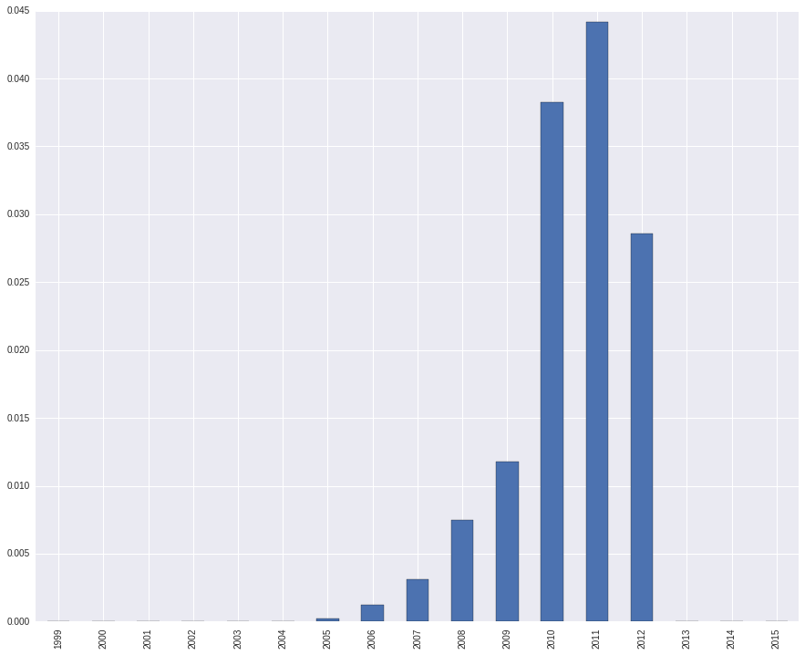

```python
default_by_year = pd.concat([total_by_year,total_default_by_year], join='outer', axis=1)#.reset_index().plot()
default_by_year['Rate'] = default_by_year['Default number']/default_by_year['Total number']
default_by_year['Rate'].plot(kind='bar')
```

## Default cases in each state each year

```python
default_by_year_state = fannie1_default.groupby([lambda x:extract_status_year(fannie1,'Monthly_Rpt_Prd',x),
                                                 'STATE'])['LOAN_ID'].count()
```

```python
total_by_year_state = fannie1.groupby([lambda x:extract_status_year(fannie1,'Monthly_Rpt_Prd',x),
                                                 'STATE'])['LOAN_ID'].count()
```

```python
default_by_year_state.name='default_cases_by_state'
total_by_year_state.name='total_cases_by_state'
```

[output not shown]

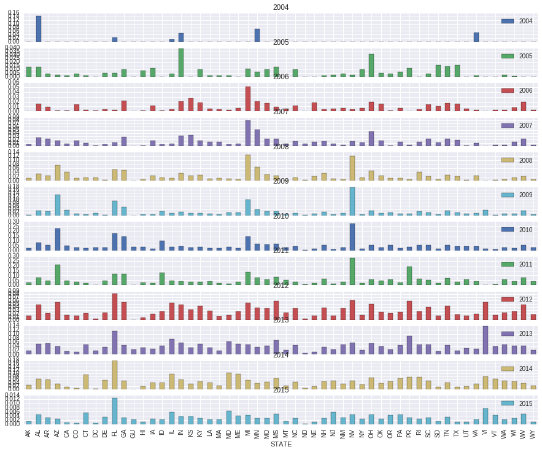

```python
default_stat_by_year_state = pd.concat([default_by_year_state,
                                      total_by_year_state], join='outer', axis=1)

default_stat_by_year_state['Rate'] = default_stat_by_year_state['default_cases_by_state']/default_stat_by_year_state['total_cases_by_state']
default_stat_by_year_state.unstack(level=0).plot(y='Rate',kind='bar',subplots=True)
```

```python
default_stat_by_year_state.sort_values(by='Rate',ascending=False)['Rate']#.unstack(level=0).plot(y='Rate',kind='bar',subplots=True)
```

```
      STATE
2011  NV       0.278939
2010  NV       0.275126
      AZ       0.229078
2011  AZ       0.208608
      PR       0.191977
2014  FL       0.179002
2009  NV       0.175793
2010  FL       0.172649
      GA       0.142972
2004  AL       0.142857
2010  MI       0.142426
2013  VI       0.138462
2011  MI       0.135645
2009  AZ       0.129435
2011  ID       0.125779
2008  MI       0.125082
      NV       0.119600
2011  GA       0.117003
      FL       0.115594
2013  FL       0.114975
2014  MD       0.104205
2010  ID       0.100582
2009  MI       0.098306
2014  ME       0.095652
      IL       0.094153
      CT       0.092987
2009  FL       0.091376
2013  PR       0.088785
2011  MS       0.082735
2012  FL       0.081037
                 ...
2004  WI            NaN
      WV            NaN
      WY            NaN
2005  DC            NaN
      ID            NaN
      KS            NaN
      ME            NaN
      MT            NaN
```

[output cut: 8 more lines]

```
2006  AK            NaN
      GU            NaN
      ND            NaN
      PR            NaN
      VI            NaN
2007  GU            NaN
      VI            NaN
2008  GU            NaN
      VI            NaN
2009  GU            NaN
2011  GU            NaN
      VI            NaN
2012  GU            NaN
2014  GU            NaN
Name: Rate, dtype: float64
```

## Default case by their credit score

### Distribution of credit score

```python
fannie1['CSCORE'].describe()
```

```
count    9.988642e+06
mean     7.434335e+02
std      5.308873e+01
min      3.200000e+02
25%      7.090000e+02
50%      7.570000e+02
75%      7.860000e+02
max      8.500000e+02
Name: CSCORE, dtype: float64
```

### Credit score statistics

The average credit score of all applications is 743. This is a little bit surprising. I don't know what credit agency do these score come from. But if it is FICO, then average potential home owner has a **excellent credit score** based on the article [here](https://finance.yahoo.com/news/average-fico-score-hits-time-113031087.html). If you have credit score less than 700 then you are already at only 25% percentile!

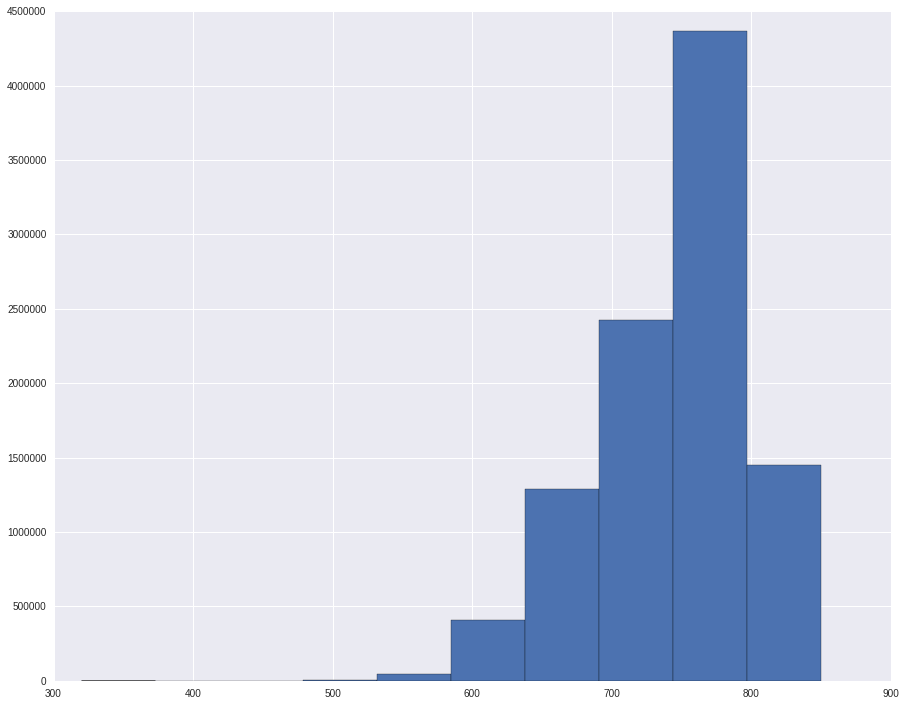

```python
fannie1['CSCORE'].hist()
```

```python
total_by_loan_status = fannie1.groupby([lambda x: extract_status_default(fannie1, x),
                                        lambda x:extract_status_year(fannie1,'ORIG_DTE',x)])['CSCORE'].mean()
```

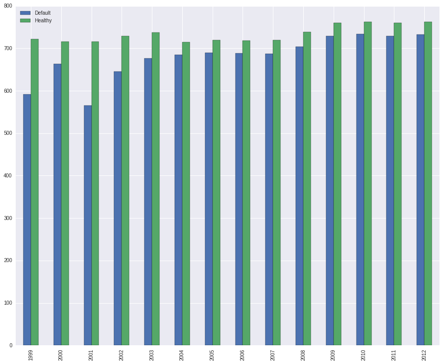

```python
total_by_loan_status.unstack(level=0).plot(kind='bar')
```

### Loan Status and Its credit score

This graph shows some interesting findings:

1. The overall trend of applicant's credit score is increasing by year.
2. Default cases **does** have lower average credit score compared to non-default cases. Therefore, credit score should be considered as one feature in the following machine learning model.
3. In the early days, you can get a loan with a low score less than 700 in 1999 and 2000. But this is not the case anymore. Tighter regulations make the rule of housing loan more and more strict, which is definitely a good thing.

## Initial Loan-to-Value ratio by status

```python
LTV_by_loan_status = fannie1.groupby([lambda x: extract_status_default(fannie1, x),
                                        lambda x:extract_status_year(fannie1,'ORIG_DTE',x)])['OLTV'].mean()
```

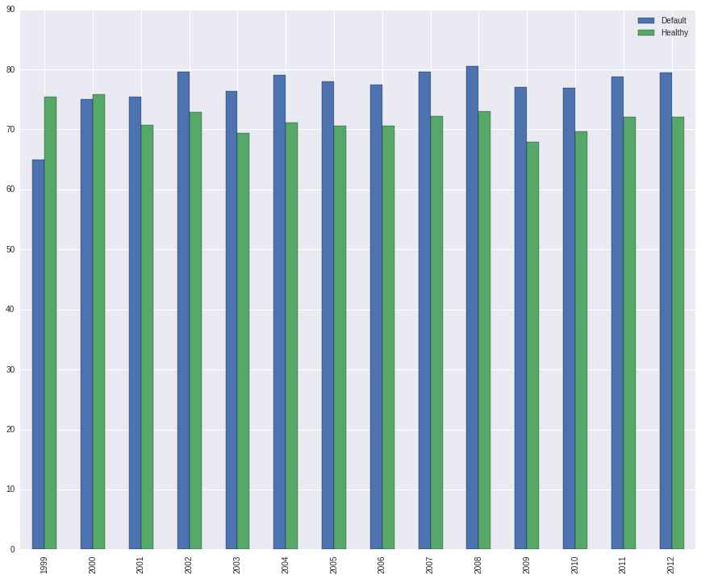

```python
LTV_by_loan_status.unstack(level=0).plot(kind='bar')
```

### Loan to value ratio (LTV)

Another interesting plot. Clearly, healthy loan has LTVs around 70%, while default cases are at 80%. This makes sense too. As higher LTV means you borrow more money to buy the house, which makes the mortgage riskier.

## Debt-to-Income ratio

```python
DTI_by_loan_status = fannie1.groupby([lambda x: extract_status_default(fannie1, x),
                                        lambda x:extract_status_year(fannie1,'ORIG_DTE',x)])['DTI'].mean()
```

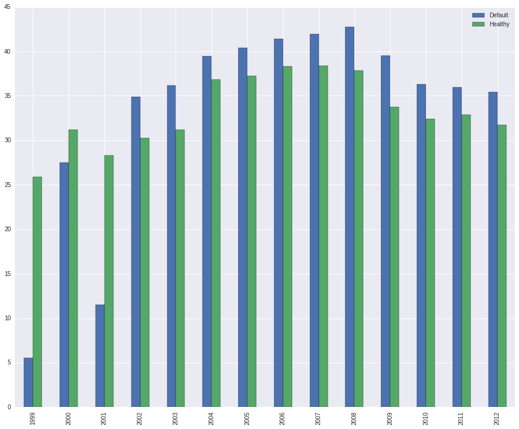

```python
DTI_by_loan_status.unstack(level=0).plot(kind='bar')
```

### Debt-to-Income ratio (DTI)

There are a lot of websites out there to tell you how much you can afford to buy a house. Like [this one](http://www.realtor.com/mortgage/tools/affordability-calculator/). The conservative approach uses ~37% as DTI and the aggressive uses 41%. Analysis of Fannie's data kind of supports this theory. Default cases in general has higher DTI compared to those non-default cases. Also, before the sub-prime crisis, you can get a loan with DTI higher than 40%. Now, the general trend of DTI becomes more and more conservative. DTI rates are now between 30-35%. So next time when you use the online house affordability calculator. Keep this in mind that the *conservative* approach is really the approach you should take. Don't bother with the "aggressive" approach...

## Loan purpose analysis

```python
purpose_status = fannie1.groupby([lambda x: extract_status_default(fannie1, x), 'PURPOSE'])['LOAN_ID'].count()
```

```python
purpose_status = purpose_status.unstack(level=0)
```

```python
purpose_status['Default_Ratio'] = purpose_status['Default']/purpose_status['Healthy']
purpose_status
```

| PURPOSE | Default | Healthy | Default_Ratio |
| --- | --- | --- | --- |
| C | 144821 | 2822240 | 0.051314 |
| P | 118948 | 3889445 | 0.030582 |
| R | 74859 | 2949208 | 0.025383 |
| U | 30 | 449 | 0.066815 |

### Loan purpose comments

| Code | Purpose |
| --- | --- |
| C | Cash-out refinance |
| P | Purchase |
| R | Refinance |
| U | Unspecified refinance |

Keep in mind that overall default rate is `0.0247709`. [Cash out refinance](http://www.bankrate.com/finance/financial-literacy/when-is-cash-out-refinancing-a-good-option--1.aspx) has relatively higher default rate compared to other types. If you think about why, click the link and read what "cash-out refinance" means and you would know why.

## Occupancy status analysis

```python
occupancy_status = fannie1.groupby([lambda x: extract_status_default(fannie1, x), 'OCC_STAT'])['LOAN_ID'].count()

occupancy_status = occupancy_status.unstack(level=0)
```

```python
occupancy_status['Default_Ratio'] = occupancy_status['Default']/occupancy_status['Healthy']
occupancy_status
```

| OCC_STAT | Default | Healthy | Default_Ratio |
| --- | --- | --- | --- |
| I | 39882 | 743727 | 0.053625 |
| P | 283148 | 8421442 | 0.033622 |
| S | 15628 | 496173 | 0.031497 |

### Occupancy status comments

| Code | Status |
| --- | --- |
| I | Investment |
| P | Primary |
| S | Secondary |

Very simple conclusion: Investment type occupancy status has a relatively higher default rate.

## Geo-Location analysis

```python
location_default = fannie1.groupby([lambda x: extract_status_default(fannie1, x), 'STATE'])['LOAN_ID'].count()
location_total = fannie1.groupby(['STATE'])['LOAN_ID'].count()
location_default_stat = pd.concat([location_default.unstack(level=0),location_total], axis = 1, join='inner')

location_default_stat.columns = ['Default', 'Healthy', 'Total']

location_default_stat['Default_Ratio'] = location_default_stat['Default']/location_default_stat['Total']
```

```python
location_default_mean = location_default_stat['Default_Ratio'].mean()
location_default_std = location_default_stat['Default_Ratio'].std()
```

### States have higher than mean + 1.5 sigma default rate?

```python
location_default_stat[location_default_stat['Default_Ratio'] > location_default_mean + 1.5*location_default_std]
```

| STATE | Default | Healthy | Total | Default_Ratio |
| --- | --- | --- | --- | --- |
| AZ | 26272 | 253459 | 279731 | 0.093919 |
| FL | 53461 | 470288 | 523749 | 0.102074 |
| MI | 17551 | 230956 | 248507 | 0.070626 |
| NV | 10551 | 77884 | 88435 | 0.119308 |

### Geo based default statistics

I am very surprised about this analysis. Those four states have higher default rate (more than 1.5$\sigma$ higher than the mean). I thought they would be CA, TX etc. But none of them are at the top of the list. In fact, Nevada is the state with highest default rate, followed by Florida.